# Quiz 230315

coop711

2023-03-15

## Red, Black을 잘못 표시한 사람들

랜덤화출석부에 있는 Red, Black 과 실제 구글예습퀴즈에 올린 Red, Black 이 여전히 다른 사람들이 있어서 파악해 보았습니다. Red를 Black 이라고 한 사람의 수효(22명)와 Black을 Red 라고 한 사람의 수효(15명)에 차이가 많이 나는 것처럼 보이지만 37명을 랜덤하게 둘로 나누면 18.5명 $\pm\sqrt37/2$명 = 18.5 $\pm$ 3 명의 범위에 들 것으로 기대되는 데 범위를 살짝 벗어나는 수준입니다. 굳이 학번까지 올린 이유는 그 다음 구글예습퀴즈부터라도 제대로 올려주길 바라서입니다.

| 학번 | 랜덤화출석부 | 구글예습퀴즈 |
| --- | --- | --- |
| 20132720 | Red | Black |
| 20175161 | Black | Red |
| 20181102 | Red | Black |
| 20182881 | Red | Black |
| 20182946 | Red | Black |
| 20183716 | Red | Black |
| 20191509 | Red | Black |
| 20201506 | Black | Red |
| 20202541 | Red | Black |
| 20203329 | Red | Black |
| 20206611 | Red | Black |
| 20206615 | Black | Red |
| 20212634 | Black | Red |
| 20213341 | Red | Black |
| 20213424 | Red | Black |
| 20213929 | Red | Black |
| 20215114 | Red | Black |
| 20221073 | Black | Red |
| 20221523 | Red | Black |
| 20221526 | Red | Black |
| 20221531 | Black | Red |
| 20221607 | Red | Black |
| 20222108 | Black | Red |
| 20222413 | Red | Black |
| 20222722 | Red | Black |
| 20222742 | Red | Black |
| 20222760 | Red | Black |
| 20223948 | Red | Black |
| 20226119 | Black | Red |
| 20226176 | Black | Red |
| 20232619 | Black | Red |
| 20232714 | Black | Red |
| 20233014 | Black | Red |
| 20233254 | Red | Black |
| 20235127 | Black | Red |
| 20236703 | Black | Red |
| 20236789 | Black | Red |

|  | Red(구글예습퀴즈) | Black(구글예습퀴즈) |
| --- | --- | --- |
| **Red(랜덤화출석부)** | 439 | 22 |
| **Black(랜덤화출석부)** | 15 | 438 |

# 퀴즈 응답 비교

## Q1. 국세와 지방세 비중

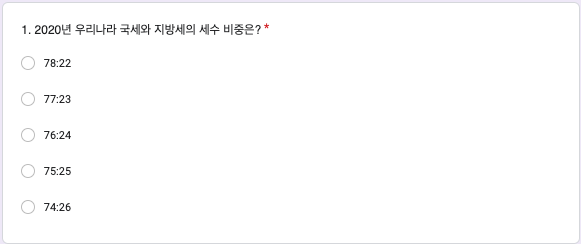

### 국세와 지방세 비중(집계표)

|  | 78:22 | 77:23 | 76:24 | 75:25 | 74:26 | 계 |
| --- | --- | --- | --- | --- | --- | --- |
| **Red** | 27 | 68 | 56 | 56 | 247 | 454 |
| **Black** | 30 | 52 | 83 | 54 | 241 | 460 |
| **계** | 57 | 120 | 139 | 110 | 488 | 914 |

Pearson’s Chi-squared test with simulated p-value (based on 2000 replicates): `.`

| Test statistic | df | P value |
| --- | --- | --- |
| 7.607 | NA | 0.09345 |

### 국세와 지방세 비중(%)

| 78:22 | 77:23 | 76:24 | 75:25 | 74:26 | 계 |
| --- | --- | --- | --- | --- | --- |
| 6.2 | 13.1 | 15.2 | 12.0 | 53.4 | 100.0 |

## Q2. 조세부담률

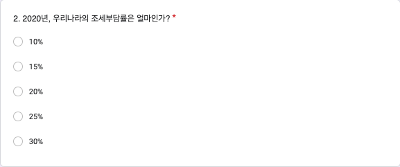

### 조새부담률(집계표)

|  | 10% | 15% | 20% | 25% | 30% | 계 |
| --- | --- | --- | --- | --- | --- | --- |
| **Red** | 21 | 42 | 321 | 54 | 16 | 454 |
| **Black** | 22 | 57 | 312 | 48 | 21 | 460 |
| **계** | 43 | 99 | 633 | 102 | 37 | 914 |

Pearson’s Chi-squared test with simulated p-value (based on 2000 replicates): `.`

| Test statistic | df | P value |
| --- | --- | --- |
| 3.413 | NA | 0.4958 |

### 조새부담률(%)

| 10% | 15% | 20% | 25% | 30% | 계 |
| --- | --- | --- | --- | --- | --- |
| 4.7 | 10.8 | 69.3 | 11.2 | 4.0 | 100.0 |

## Q3. OECD 국민부담률

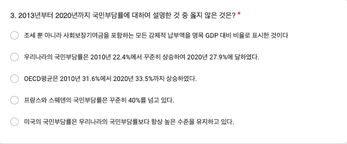

### OECD 국민부담률(집계표)

|  | 조세 뿐 아니라 사회보장기여금을 포함하는 모든 강제적 납부액을 명목 GDP 대비 비율로 표시한 것이다 | 우리나라의 국민부담률은 2010년 22.4%에서 꾸준히 상승하여 2020년 27.9%에 달하였다. | OECD평균은 2010년 31.6%에서 2020년 33.5%까지 상승하였다. | 프랑스와 스웨덴의 국민부담률은 꾸준히 40%를 넘고 있다. | 미국의 국민부담률은 우리나라의 국민부담률보다 항상 높은 수준을 유지하고 있다. | 계 |
| --- | --- | --- | --- | --- | --- | --- |
| **Red** | 38 | 85 | 49 | 58 | 224 | 454 |
| **Black** | 43 | 73 | 57 | 71 | 216 | 460 |
| **계** | 81 | 158 | 106 | 129 | 440 | 914 |

Pearson’s Chi-squared test with simulated p-value (based on 2000 replicates): `.`

| Test statistic | df | P value |
| --- | --- | --- |
| 3.24 | NA | 0.5327 |

### OECD 국민부담률(%)

| 조세 뿐 아니라 사회보장기여금을 포함하는 모든 강제적 납부액을 명목 GDP 대비 비율로 표시한 것이다 | 우리나라의 국민부담률은 2010년 22.4%에서 꾸준히 상승하여 2020년 27.9%에 달하였다. | OECD평균은 2010년 31.6%에서 2020년 33.5%까지 상승하였다. | 프랑스와 스웨덴의 국민부담률은 꾸준히 40%를 넘고 있다. | 미국의 국민부담률은 우리나라의 국민부담률보다 항상 높은 수준을 유지하고 있다. | 계 |
| --- | --- | --- | --- | --- | --- |
| 8.9 | 17.3 | 11.6 | 14.1 | 48.1 | 100.0 |

## Q4. 과세대상 근로소득 1,200만 원

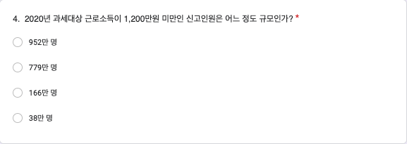

### 과세대상 근로소득 1,200만 원(집계표)

|  | 952만 명 | 779만 명 | 166만 명 | 38만 명 | 계 |
| --- | --- | --- | --- | --- | --- |
| **Red** | 224 | 128 | 87 | 15 | 454 |
| **Black** | 229 | 113 | 92 | 26 | 460 |
| **계** | 453 | 241 | 179 | 41 | 914 |

Pearson’s Chi-squared test: `.`

| Test statistic | df | P value |
| --- | --- | --- |
| 4.04 | 3 | 0.2571 |

### 과세대상 근로소득 1,200만 원(%)

| 952만 명 | 779만 명 | 166만 명 | 38만 명 | 계 |
| --- | --- | --- | --- | --- |
| 49.6 | 26.4 | 19.6 | 4.5 | 100.0 |

## Q5. 소득세 실효세율

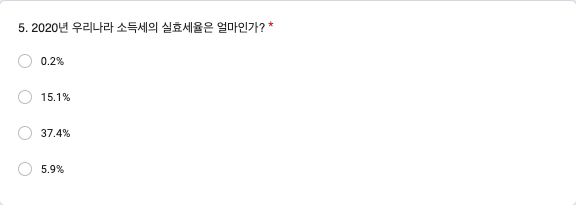

### 소득세 실효세율(집계표)

|  | 0.2% | 15.1% | 37.4% | 5.9% | 계 |
| --- | --- | --- | --- | --- | --- |
| **Red** | 21 | 115 | 61 | 257 | 454 |
| **Black** | 24 | 124 | 55 | 257 | 460 |
| **계** | 45 | 239 | 116 | 514 | 914 |

Pearson’s Chi-squared test: `.`

| Test statistic | df | P value |
| --- | --- | --- |
| 0.8099 | 3 | 0.8471 |

### 소득세 실효세율(%)

| 0.2% | 15.1% | 37.4% | 5.9% | 계 |
| --- | --- | --- | --- | --- |
| 4.9 | 26.1 | 12.7 | 56.2 | 100.0 |

## Q6. 기업규모별 과세 현황

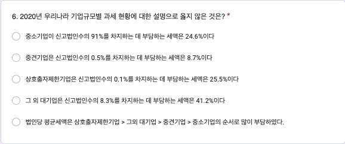

### 기업규모별 과세 현황(집계표)

|  | 중소기업이 신고법인수의 91%를 차지하는 데 부담하는 세액은 24.6%이다 | 중견기업은 신고법인수의 0.5%를 차지하는 데 부담하는 세액은 8.7%이다 | 상호출자제한기업은 신고법인수의 0.1%를 차지하는 데 부담하는 세액은 25.5%이다 | 그 외 대기업은 신고법인수의 8.3%를 차지하는 데 부담하는 세액은 41.2%이다 | 법인당 평균세액은 상호출자제한기업 > 그외 대기업 > 중견기업 > 중소기업의 순서로 많이 부담하였다. | 계 |
| --- | --- | --- | --- | --- | --- | --- |
| **Red** | 52 | 89 | 73 | 58 | 182 | 454 |
| **Black** | 35 | 78 | 72 | 68 | 207 | 460 |
| **계** | 87 | 167 | 145 | 126 | 389 | 914 |

Pearson’s Chi-squared test: `.`

| Test statistic | df | P value |
| --- | --- | --- |
| 6.415 | 4 | 0.1703 |

### 기업규모별 과세 현황(%)

| 중소기업이 신고법인수의 91%를 차지하는 데 부담하는 세액은 24.6%이다 | 중견기업은 신고법인수의 0.5%를 차지하는 데 부담하는 세액은 8.7%이다 | 상호출자제한기업은 신고법인수의 0.1%를 차지하는 데 부담하는 세액은 25.5%이다 | 그 외 대기업은 신고법인수의 8.3%를 차지하는 데 부담하는 세액은 41.2%이다 | 법인당 평균세액은 상호출자제한기업 > 그외 대기업 > 중견기업 > 중소기업의 순서로 많이 부담하였다. | 계 |
| --- | --- | --- | --- | --- | --- |
| 9.5 | 18.3 | 15.9 | 13.8 | 42.6 | 100.0 |

# 국민부담률 적정 수준

## Q7. 아일랜드와 OECD 평균

질문 내용에 의도하는 바를 담으면 어떨까요? OECD 국가 중 국민부담률이 매우 낮은 편이 아일랜드의 사례를 들어서 감세정책이 가져온 긍정적적인 효과에 대해서 설명하고 우리나라의 바람직한 조정 방향은 무엇이냐고 묻는 것을 Red, 감세 정책이 가져온 부정적인 효과에서 대해서 설명하고 우리나라의 바람직한 조정 방향은 무엇이냐고 묻는 것을 Black 에 배치했을 때, 설명이 영향을 미치지 않으면 Red 와 Black에 차이가 없어야 할텐데 집계결과는 어떻게 나오고 있나요? 분명히 영향을 미치고 있는 것으로 보입니다. 통계적으로 매우 유의한 차이가 관찰되고 있습니다. 감세정책의 효과가 긍정적이라고 설명한 Red 에서는 낮춰야 한다는 응답이, 감세정책의 효과가 부정적이라고 설명한 Black 에서는 높여야 한다는 응답이 높게 나온 것을 볼 수 있고, 따라서 p-value 엄청나게 작은 값을 보여주고 있습니다.

### Red

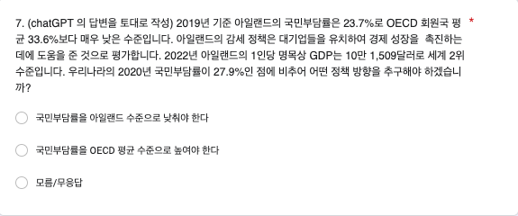

### Black

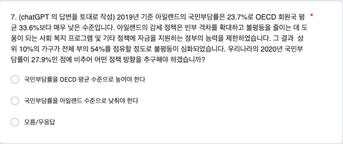

### 집계표

|  | 낮춰야 한다 | 높여야 한다 | 모름/무응답 | 계 |
| --- | --- | --- | --- | --- |
| **Red(감세의 긍정적효과 설명)** | 189 | 170 | 95 | 454 |
| **Black(감세의 부정적 효과 설명)** | 84 | 271 | 105 | 460 |
| **계** | 273 | 441 | 200 | 914 |

Pearson’s Chi-squared test: `.`

| Test statistic | df | P value |
| --- | --- | --- |
| 63.98 | 2 | 1.279e-14 * * * |

### % 비교

|  | 낮춰야 한다 | 높여야 한다 | 모름/무응답 | 계 |
| --- | --- | --- | --- | --- |
| **Red(감세의 긍정적효과 설명)** | 41.6 | 37.4 | 20.9 | 100.0 |
| **Black(감세의 부정적 효과 설명)** | 18.3 | 58.9 | 22.8 | 100.0 |

### Mosaic Plot

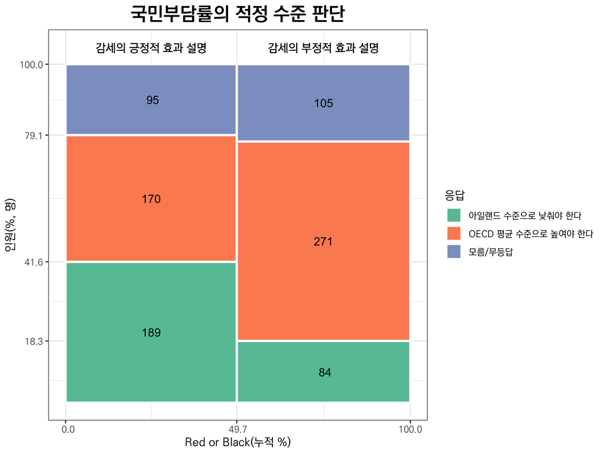

# 제출 시간의 분포

과제 제출이 제출 기간 마지막 날에 몰린다는 것을 시각적으로 보여주고 싶어서 하나 추가하였습니다. 아직은 학기초라 덜 한데, 중반 이후가 되면 마지막 날, 그것도 오후2시부터 몰리는 현상을 관찰할 수 있습니다. 여기서조차 랜덤화 효과를 관찰할 수 있네요. p-value 에 유의해 주세요. 제출시간과 관련한 두 가지 현상에 대해서도 여러분의 생각을 들어보고 싶습니다. 첫째, 랜덤화 효과. 둘쨰, 마감날에 몰리는 현상.

### 일 단위 마감 시간으로부터 제출 시간의 분포

일 단위

|  | [0,1] | (1,2] | (2,3] | (3,4] | (4,5] | (5,6] | (6,7] | (7,8] | (8,9] | (9,10] | (10,11] | (11,12] | (12,13] | (13,14] |
| --- | --- | --- | --- | --- | --- | --- | --- | --- | --- | --- | --- | --- | --- | --- |
| **Red** | 127 | 51 | 33 | 11 | 19 | 7 | 18 | 21 | 32 | 28 | 30 | 23 | 20 | 34 |
| **Black** | 109 | 53 | 29 | 10 | 25 | 19 | 19 | 26 | 38 | 29 | 24 | 27 | 19 | 33 |

Pearson’s Chi-squared test: `.`

| Test statistic | df | P value |
| --- | --- | --- |
| 10.15 | 13 | 0.6814 |

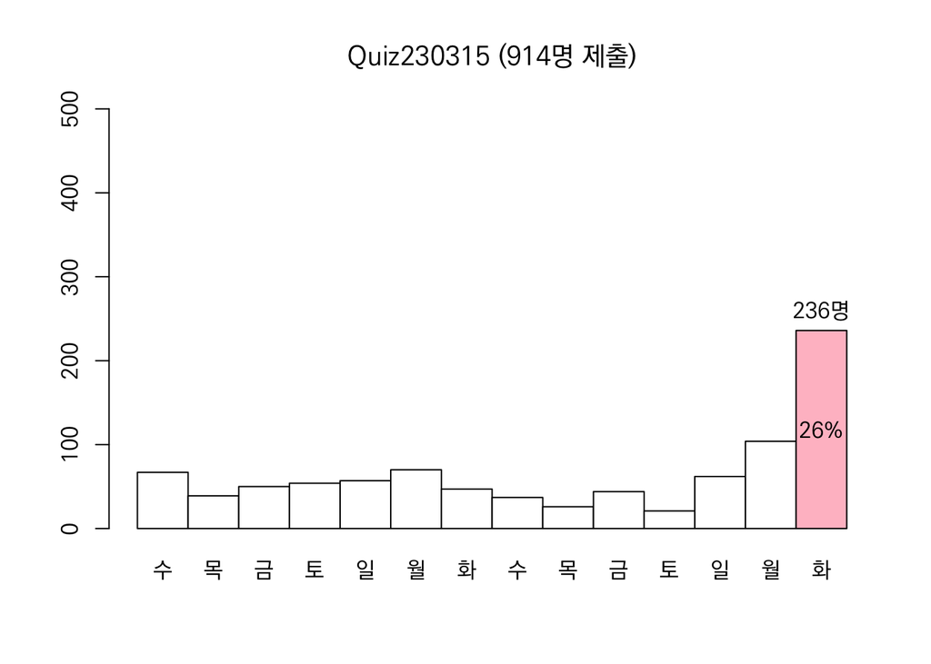